# Reproducible Research: Peer Assessment 1

Author : just Me

This Document was created on Sat Jul 19 04:52:02 PM 2014.

# Intention:

Solve the question for the Reproducible Research Peer Assessment 1 to get a cousera certificate.

# Introduction

It is now possible to collect a large amount of data about personal movement using activity monitoring devices such as a [Fitbit](http://www.fitbit.com), [Nike Fuelband](http://www.nike.com/us/en_us/c/nikeplus-fuelband), or[Jawbone Up](https://jawbone.com/up). These type of devices are part of the “quantified self” movement – a group of enthusiasts who take measurements about themselves regularly to improve their health, to find patterns in their behavior, or because they are tech geeks. But these data remain under-utilized both because the raw data are hard to obtain and there is a lack of statistical methods and software for processing and interpreting the data.

## Loading and preprocessing the data

The orginal raw-data which I downloaded from the GITHUB repository from Roger Peng.

https://github.com/rdpeng/RepData_PeerAssessment1 on the monday the 07 July 2014.

```r
# read rawdata
rdata <- read.csv("./rawdata/activity.csv",sep=",")
#names
names(rdata)
```

```
## [1] "steps"    "date"     "interval"
```

```r
# show header ( 3 rows)
head(rdata,n=3)
```

```
##   steps       date interval
## 1    NA 2012-10-01        0
## 2    NA 2012-10-01        5
## 3    NA 2012-10-01       10
```

```r
# summary rdata
summary(rdata)
```

```
##      steps               date          interval
##  Min.   :  0.0   2012-10-01:  288   Min.   :   0
##  1st Qu.:  0.0   2012-10-02:  288   1st Qu.: 589
##  Median :  0.0   2012-10-03:  288   Median :1178
##  Mean   : 37.4   2012-10-04:  288   Mean   :1178
##  3rd Qu.: 12.0   2012-10-05:  288   3rd Qu.:1766
##  Max.   :806.0   2012-10-06:  288   Max.   :2355
##  NA's   :2304    (Other)   :15840
```

After I inspect the raw-data us above I did some Processing on the raw-data to create useful data formats. 1. Copy radata to tidydata. 2. Convert the Column date in as.Date format 3. Build a POSIXct dataframe from the date and interval columns, so i can use POSIX function.

```r
# convert date in R convertible Date-format
tidy_data <- as.data.frame(rdata)
tidy_data$date <- as.Date(as.character(tidy_data$date))
## as date and time

tidy_date1 <- as.character(paste(tidy_data$date,sprintf("%04d",tidy_data$interval)))
xdate <- strftime(tidy_date1,format="%y-%m-%d %H:%M")
xdate <- as.POSIXct(xdate)
head(xdate)
```

```
## [1] "12-10-01 CET" "12-10-01 CET" "12-10-01 CET" "12-10-01 CET"
## [5] "12-10-01 CET" "12-10-01 CET"
```

# What is mean total number of steps taken per day?

There are NA values in the tidy-dataset, but for this questions I ignored the missing values in the dataset.

## Make a histogram of the total number of steps taken each day.

I count the sum of step per each day and plot a histogram. Therefor i use the library(ggplot2) The output figure I saves in the directory ./figures

```r
sum_pday <- aggregate(cbind(steps) ~ date, tidy_data, sum,na.rm=TRUE)
head(sum_pday,n=3)
```

```
##         date steps
## 1 2012-10-02   126
## 2 2012-10-03 11352
## 3 2012-10-04 12116
```

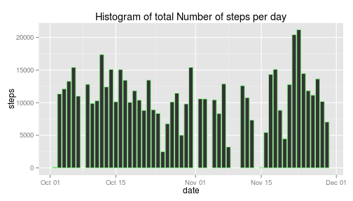

## Mean and Median

### Mean

```r
# mean per day
mean_pday <- aggregate(cbind(steps) ~ date, tidy_data, mean,na.rm=F)
head(mean_pday,n=3)
```

```
##         date   steps
## 1 2012-10-02  0.4375
## 2 2012-10-03 39.4167
## 3 2012-10-04 42.0694
```

### Median

```r
median_alldays <- median(mean_pday$steps)
median_alldays
```

```
## [1] 37.38
```

### What is the average daily activity pattern?

Make a time series plot (i.e. `type = "l"`) of the 5-minute interval (x-axis) and the average number of steps taken, averaged across all days (y-axis) mean per 5 minute interval**

```r
# q2 mean per interval
mean_pint <- aggregate(cbind(steps) ~ interval, tidy_data, mean,na.rm=F)
head(mean_pint,n=3)
```

```
##   interval  steps
## 1        0 1.7170
## 2        5 0.3396
## 3       10 0.1321
```

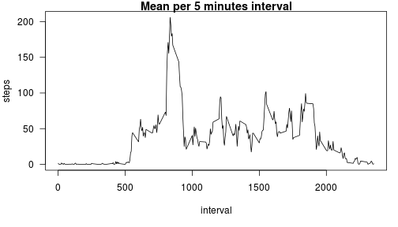

```r
# max step in all steps
xmax <-grep(max(tidy_data$steps, na.rm = T), tidy_data$steps)
tidy_data[xmax:xmax,]
```

```
##       steps       date interval
## 16492   806 2012-11-27      615
```

# Imputing missing values

Calculate and report the total number of missing values in the dataset (i.e. the total number of rows with `NA`s)

```r
# max na in dataset
sum(is.na(tidy_data$steps))
```

```
## [1] 2304
```

# Strategy for filling in all of the missing values in the dataset.

## Solution:

Copy tidy_data set to new dataset called tidy_data_nNa I will use the is.na function to fix out which value is NA, count with the mean funtion the mean of the column steps and change NA value with the mean value. I have to use na.rm= TRUE for the mean counting because otherwise the mean would NA.

Create a new dataset that is equal to the original dataset but with the missing data filled in.

```r
# q3-3
tidy_data_nNa <- tidy_data
tidy_data_nNa$steps[is.na(tidy_data_nNa$steps)] <- mean(tidy_data_nNa$steps, na.rm = TRUE)
# str
str(tidy_data_nNa)
```

```
## 'data.frame':    17568 obs. of  3 variables:
##  $ steps   : num  37.4 37.4 37.4 37.4 37.4 ...
##  $ date    : Date, format: "2012-10-01" "2012-10-01" ...
##  $ interval: int  0 5 10 15 20 25 30 35 40 45 ...
```

```r
# summary ne data.frame tidy_data_nNa
summary(tidy_data_nNa)
```

```
##      steps            date               interval
##  Min.   :  0.0   Min.   :2012-10-01   Min.   :   0
##  1st Qu.:  0.0   1st Qu.:2012-10-16   1st Qu.: 589
##  Median :  0.0   Median :2012-10-31   Median :1178
##  Mean   : 37.4   Mean   :2012-10-31   Mean   :1178
##  3rd Qu.: 37.4   3rd Qu.:2012-11-15   3rd Qu.:1766
##  Max.   :806.0   Max.   :2012-11-30   Max.   :2355
```

```r
# show head of tidy_data_nNa
head(tidy_data_nNa)
```

```
##   steps       date interval
## 1 37.38 2012-10-01        0
## 2 37.38 2012-10-01        5
## 3 37.38 2012-10-01       10
## 4 37.38 2012-10-01       15
## 5 37.38 2012-10-01       20
## 6 37.38 2012-10-01       25
```

## Histogram

Make a histogram of the total number of steps taken each day and Calculate and report the **mean** and **median** total number of steps taken per day.

## Compare dataset with and without NA's

```r
sum_pday_nNa <- aggregate(cbind(tidy_data_nNa$steps)~ tidy_data_nNa$date,tidy_data_nNa, sum,na.rm=TRUE)
sum_pday <- aggregate(cbind(steps) ~ date, tidy_data, sum,na.rm=TRUE)
head(sum_pday)
```

```
##         date steps
## 1 2012-10-02   126
## 2 2012-10-03 11352
## 3 2012-10-04 12116
## 4 2012-10-05 13294
## 5 2012-10-06 15420
## 6 2012-10-07 11015
```

```r
head(sum_pday_nNa)
```

```
##   tidy_data_nNa$date    V1
## 1         2012-10-01 10766
## 2         2012-10-02   126
## 3         2012-10-03 11352
## 4         2012-10-04 12116
## 5         2012-10-05 13294
## 6         2012-10-06 15420
```

## Str and summary from dataset with none NA's

```r
# q3-4
str(sum_pday_nNa)
```

```
## 'data.frame':    61 obs. of  2 variables:
##  $ tidy_data_nNa$date: Date, format: "2012-10-01" "2012-10-02" ...
##  $ V1                : num  10766 126 11352 12116 13294 ...
```

```r
summary(sum_pday_nNa)
```

```
##  tidy_data_nNa$date         V1
##  Min.   :2012-10-01   Min.   :   41
##  1st Qu.:2012-10-16   1st Qu.: 9819
##  Median :2012-10-31   Median :10766
##  Mean   :2012-10-31   Mean   :10766
##  3rd Qu.:2012-11-15   3rd Qu.:12811
##  Max.   :2012-11-30   Max.   :21194
```

## Histogram with none Na in dataset

[figure not shown]

## Calculate and report the mean and median

Total number of steps taken per day

### Mean of all step with no NA

```r
mean_pday_nNa <- aggregate(cbind(steps) ~ date, tidy_data_nNa, mean,na.rm=F)
head(mean_pday_nNa)
```

```
##         date   steps
## 1 2012-10-01 37.3826
## 2 2012-10-02  0.4375
## 3 2012-10-03 39.4167
## 4 2012-10-04 42.0694
## 5 2012-10-05 46.1597
## 6 2012-10-06 53.5417
```

### Median of all step with no NA**

```r
median_alldays_nNa <- median(mean_pday_nNa$steps)
median_alldays_nNa
```

```
## [1] 37.38
```

## Are there differences in activity patterns between weekdays and weekends?

I use the filled NA dataset. I create a new factor variable in the dataset with two levels – “weekday” and “weekend” indicating whether a given date is a weekday or weekend day.

## Answer:

```r
#  weekday and weekend
week <- as.factor(weekdays(as.Date(as.character(xdate))) %in% c('Sunday','Saturday'))
table(week)
```

```
## week
## FALSE  TRUE
## 12960  4608
```

```r
levels ( week ) <- c ( "weekday" , "weekend" )
```

```r
mean_pweek <- aggregate(cbind(steps) ~ week, tidy_data_nNa, mean,na.rm=F)
mean_pweek
```

```
##      week steps
## 1 weekday 35.61
## 2 weekend 42.37
```

### sum per weekday and weekend

```r
sum_pweek <- aggregate(cbind(steps) ~ week, tidy_data_nNa, sum,na.rm=F)
sum_pweek
```

```
##      week  steps
## 1 weekday 461513
## 2 weekend 195224
```

## xyplot type line steps per weekdays and weekend

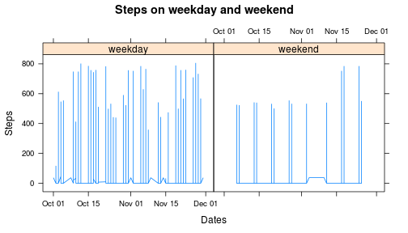

# Resent conclusions

After I finished the work with data about personal movement using activity monitoring devices, I could get interesting result, that you can see above in the workbench. It is very interesting to count and visualize the personal monitoring dataset. For everyone it would be interesting to know more about his own activity. I will suggest that theses small a personal activity monitoring device, will have a big future.